# t4

2023-09-30

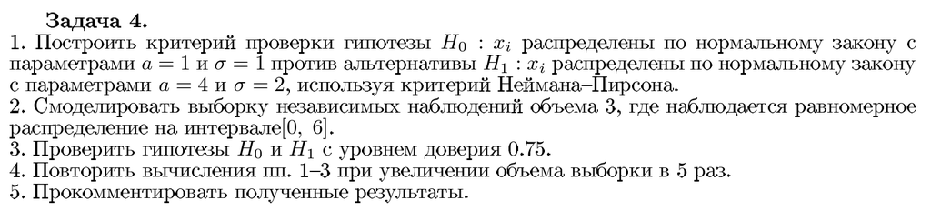

$$\delta (x) = 1
\iff \frac{p_0(x)}{p_1(x)} \le c$$

$$c: \mathbb{P}_0(\delta =1 ) \le
\alpha$$

$$\begin{aligned}
\frac{p_0(x)}{p_1(x)} \propto
\frac{
\sigma_1 \exp( \frac{ (x-\mu_0)^2 }{-2 \sigma_0 ^ 2})
}{
\sigma_0 \exp( \frac{ (x-\mu_1)^2 }{-2 \sigma_1 ^ 2} )
}
\\ \propto
\frac{\sigma_1}{\sigma_0} \exp(\frac{ \sigma_1^2 (x-\mu_0)^2 -
\sigma_0^2 (x-\mu_1)^2 }{-2 \sigma_0 ^ 2 \sigma_1 ^ 2})
\\ \propto
\frac{\sigma_1}{\sigma_0} \exp( \frac {(x - \frac{\sigma_1^2 \mu_0 -
\sigma_0 ^ 2 \mu_1}{\sigma_1 ^ 2 - \sigma_0 ^ 2} )^2}
{-2(\frac{\sigma_0^2 \sigma_1^2}{\sigma_1^2 - \sigma_0^2})} )
\end{aligned}$$

Значит, предполагая
$$\sigma_1 >
\sigma_0$$
(в нашем случае это так) (значит $-2(\frac{\sigma_0^2 \sigma_1^2}{\sigma_1^2 - \sigma_0^2}) < 0$),

$$\begin{aligned}
\delta (x) = 1 \iff \\
\log\frac{\sigma_1}{\sigma_0} + \frac {(x - \frac{\sigma_1^2 \mu_0 -
\sigma_0 ^ 2 \mu_1}{\sigma_1 ^ 2 - \sigma_0 ^ 2} )^2}
{-2(\frac{\sigma_0^2 \sigma_1^2}{\sigma_1^2 - \sigma_0^2})} \le c \iff
\\
(x - \frac{\sigma_1^2 \mu_0 - \sigma_0 ^ 2 \mu_1}{\sigma_1 ^ 2 -
\sigma_0 ^ 2} )^2 \ge -2(\frac{\sigma_0^2 \sigma_1^2}{\sigma_1^2 -
\sigma_0^2})(c - \log\frac{\sigma_1}{\sigma_0}) \iff \\
(x - \frac{\sigma_1^2 \mu_0 - \sigma_0 ^ 2 \mu_1}{\sigma_1 ^ 2 -
\sigma_0 ^ 2} )^2 \ge c'
\end{aligned}$$

Таким образом,

$$\begin{aligned}
\delta(\mathbf{X}) = 0 \iff \\
\sum{\log\frac{p_0(x_i)}{p_1(x_i)}} \le c \iff \\
\sum( \log\frac{\sigma_1}{\sigma_0} + \frac {(x_i - \frac{\sigma_1^2
\mu_0 - \sigma_0 ^ 2 \mu_1}{\sigma_1 ^ 2 - \sigma_0 ^ 2} )^2}
{-2(\frac{\sigma_0^2 \sigma_1^2}{\sigma_1^2 - \sigma_0^2})}) \le c \iff
\\
N\log\frac{\sigma_1}{\sigma_0} + \frac {\sum (x_i - \frac{\sigma_1^2
\mu_0 - \sigma_0 ^ 2 \mu_1}{\sigma_1 ^ 2 - \sigma_0 ^ 2} )^2}
{-2(\frac{\sigma_0^2 \sigma_1^2}{\sigma_1^2 - \sigma_0^2})}) \le c \iff
\\
\sum_{i=1}^n (x_i - \frac{\sigma_1^2 \mu_0 - \sigma_0 ^ 2
\mu_1}{\sigma_1 ^ 2 - \sigma_0 ^ 2} ) ^ 2 \ge c'
\end{aligned}$$

$c'$ зависит от $\sigma_0$ и $\sigma_1$, но в данном случае (проверки простой гипотезы) это не важно

Порог $c'$ проще подобрать численно.

```r
alpha = 0.75
sigma_0 = 1
sigma_1 = sqrt(2)
mu_0 = 1
mu_1 = 4
mu.test = (sigma_1 ** 2 * mu_0 - sigma_0 ** 2 * mu_1) / (sigma_1 ** 2 - sigma_0 ** 2)

test_statistic = function(sample) {
  sum((sample - mu.test) ** 2)
}

bootstrap_statistic = function(statistic, mu_0, sigma_0, n_samples=100) {
  statistics = c()
  for (i in 1:1000) {
    sample = rnorm(n_samples, mean=mu_0, sd=sigma_0)
    statistics = append(statistics, statistic(sample))
  }
  statistics
}

estimate_c = function(statistics, alpha, mu_0, sigma_0) {
  for (c in seq(0, 10000, length.out=10000)) {
    alpha_c = length(statistics[statistics > c]) / length(statistics)
    if (alpha_c < alpha) {
      return(c)
    }
  }
}

get_pvalue = function(statistics, value) {
  length(statistics[statistics > value]) / length(statistics)
}
```

Оценим распределение статистик $\sum_{i=1}^n (x_i - \frac{\sigma_1^2 \mu_0 - \sigma_0 ^ 2 \mu_1}{\sigma_1 ^ 2 - \sigma_0 ^ 2} ) ^ 2$ при нулевой гипотезе при разных $n=3,15,100$ с помощью сэмплирования. Узнаем пороги c для уровня $\alpha=0.75$

```r
set.seed(2023)
statistics.3 = bootstrap_statistic(test_statistic, mu_0, sigma_0, n_samples = 3)
statistics.15 = bootstrap_statistic(test_statistic, mu_0, sigma_0, n_samples = 15)
statistics.100 = bootstrap_statistic(test_statistic, mu_0, sigma_0, n_samples = 100)

c.3 = estimate_c(statistics.3, alpha, mu_0, sigma_0)
c.15 = estimate_c(statistics.15, alpha, mu_0, sigma_0)
c.100 = estimate_c(statistics.100, alpha, mu_0, sigma_0)

list(c.3=c.3, c.15=c.15, c.100=c.100)
```

```
## $c.3
## [1] 22.0022
##
## $c.15
## [1] 135.0135
##
## $c.100
## [1] 960.096
```

Берем выборку из распределения в нулевой гипотезе размером $n=15$, считаем p-value. Гипотеза не опровергнута

```r
set.seed(2023)
sample = rnorm(15, mean=mu_0, sd=sigma_0)
statistic = test_statistic(sample)
list(
  reject =  statistic > c.15,
  pvalue = get_pvalue(statistics.15, statistic),
  c.15=c.15,
  observed.statistic=statistic
)
```

```
## $reject
## [1] FALSE
##
## $pvalue
## [1] 0.836
##
## $c.15
## [1] 135.0135
##
## $observed.statistic
## [1] 127.2479
```

Берем выборку из распределения в нулевой гипотезе размером $n=100$, считаем p-value. На удивление, гипотеза опровергнута

```r
set.seed(2023)
sample = rnorm(100, mean=mu_0, sd=sigma_0)
statistic = test_statistic(sample)
list(
  reject =  statistic > c.100,
  pvalue = get_pvalue(statistics.100, statistic),
  c.100=c.100,
  observed.statistic=statistic
)
```

```
## $reject
## [1] TRUE
##
## $pvalue
## [1] 0.281
##
## $c.100
## [1] 960.096
##
## $observed.statistic
## [1] 1038.588
```

Берем выборку из равномерного распределения в нулевой гипотезе размером $n=3$, считаем p-value. Гипотеза опровергнута

```r
set.seed(2023)
sample = runif(3, min=0, max=6)
statistic = test_statistic(sample)
list(reject =  statistic > c.3, pvalue = get_pvalue(statistics.3, statistic))
```

```
## $reject
## [1] TRUE
##
## $pvalue
## [1] 0.061
```

Берем выборку из равномерного распределения в нулевой гипотезе размером $n=15$, считаем p-value. Гипотеза опровергнута

```r
set.seed(2023)
sample = runif(15, min=0, max=6)
statistic = test_statistic(sample)
list(reject =  statistic > c.15, pvalue = get_pvalue(statistics.3, statistic))
```

```
## $reject
## [1] TRUE
##
## $pvalue
## [1] 0
```

Таким образом, статистические решения, полученные из критерия Неймана-Пирсона, могут быть применены и к выборкам, которые совсем не похожи на распределение как из нулевой гипотезы, так и из альтернативы. В тестировании гипотез по критерию Неймана-Пирсона отсутствует информация о том, насколько наблюдаемое распределение похоже на принимаемое(ые) (в результате проверки гипотез) распределение(я). В этом заключается его недостаток.